# Poisson Regression: wine sales by chemical composition

Máster en Data Science y Big Data en Finanzas

AFI, 2022

[figure not shown]

# Motivation

**Objective:** explain wine sales by chemical composition

Dataset with around 11,000 commercially wines containing chemical and other characteristics that are tasted first by wine distribution companies and then are purchased to be used in restaurants and stores

Hence, the larger the wine cases purchased, the more likely the wine will be sold in restaurants and stores

Load some packages

```r
# delete everything
rm(list=ls())

library(tidyverse)
library(GGally)
library(MASS)
library(effects)
library(pscl)
```

# The dataset

Specifically, the output (TARGET) is number of wine cases purchased by wine distribution companies

The predictors are 12 chemical properties of the wines, plus LabelAppeal (marketing score indicating the appeal of label design), plus STARS (wine rating given by experts)

```r
wine_training <- read.csv("wine-training-data.csv", header = TRUE)
wine_testing <- read.csv("wine-testing-data.csv", header = TRUE)

head(wine_training,10)
```

```
##    INDEX TARGET FixedAcidity VolatileAcidity CitricAcid ResidualSugar Chlorides
## 1      1      3          3.2           1.160      -0.98         54.20    -0.567
## 2      2      3          4.5           0.160      -0.81         26.10    -0.425
## 3      4      5          7.1           2.640      -0.88         14.80     0.037
## 4      5      3          5.7           0.385       0.04         18.80    -0.425
## 5      6      4          8.0           0.330      -1.26          9.40        NA
## 6      7      0         11.3           0.320       0.59          2.20     0.556
## 7      8      0          7.7           0.290      -0.40         21.50     0.060
## 8     11      4          6.5          -1.220       0.34          1.40     0.040
## 9     12      3         14.8           0.270       1.05         11.25    -0.007
## 10    13      6          5.5          -0.220       0.39          1.80    -0.277
##    FreeSulfurDioxide TotalSulfurDioxide Density   pH Sulphates Alcohol
## 1                 NA                268 0.99280 3.33     -0.59     9.9
## 2                 15               -327 1.02792 3.38      0.70      NA
## 3                214                142 0.99518 3.12      0.48    22.0
```

[output cut: 18 more lines]

```r
head(wine_testing,10)
```

```
##    IN TARGET FixedAcidity VolatileAcidity CitricAcid ResidualSugar Chlorides
## 1   3     NA          5.4          -0.860       0.27         -10.7     0.092
## 2   9     NA         12.4           0.385      -0.76         -19.7     1.169
## 3  10     NA          7.2           1.750       0.17         -33.0     0.065
## 4  18     NA          6.2           0.100       1.80           1.0    -0.179
## 5  21     NA         11.4           0.210       0.28           1.2     0.038
## 6  30     NA         17.6           0.040      -1.15           1.4     0.535
## 7  31     NA         15.5           0.530      -0.53           4.6     1.263
## 8  37     NA         15.9           1.190       1.14          31.9    -0.299
## 9  39     NA         11.6           0.320       0.55         -50.9     0.076
## 10 47     NA          3.8           0.220       0.31          -7.7     0.039
##    FreeSulfurDioxide TotalSulfurDioxide Density   pH Sulphates Alcohol
## 1                 23                398 0.98527 5.02      0.64   12.30
## 2                -37                 68 0.99048 3.37      1.09   16.00
## 3                  9                 76 1.04641 4.61      0.68    8.55
```

[output cut: 18 more lines]

Summary:

```r
summary(wine_training)
```

```
##      INDEX           TARGET       FixedAcidity     VolatileAcidity
##  Min.   :    1   Min.   :0.000   Min.   :-18.100   Min.   :-2.7900
##  1st Qu.: 4038   1st Qu.:2.000   1st Qu.:  5.200   1st Qu.: 0.1300
##  Median : 8110   Median :3.000   Median :  6.900   Median : 0.2800
##  Mean   : 8070   Mean   :3.029   Mean   :  7.076   Mean   : 0.3241
##  3rd Qu.:12106   3rd Qu.:4.000   3rd Qu.:  9.500   3rd Qu.: 0.6400
##  Max.   :16129   Max.   :8.000   Max.   : 34.400   Max.   : 3.6800
##
##    CitricAcid      ResidualSugar        Chlorides       FreeSulfurDioxide
##  Min.   :-3.2400   Min.   :-127.800   Min.   :-1.1710   Min.   :-555.00
##  1st Qu.: 0.0300   1st Qu.:  -2.000   1st Qu.:-0.0310   1st Qu.:   0.00
##  Median : 0.3100   Median :   3.900   Median : 0.0460   Median :  30.00
##  Mean   : 0.3084   Mean   :   5.419   Mean   : 0.0548   Mean   :  30.85
##  3rd Qu.: 0.5800   3rd Qu.:  15.900   3rd Qu.: 0.1530   3rd Qu.:  70.00
##  Max.   : 3.8600   Max.   : 141.150   Max.   : 1.3510   Max.   : 623.00
##                    NA's   :616        NA's   :638       NA's   :647
##  TotalSulfurDioxide    Density             pH          Sulphates
##  Min.   :-823.0     Min.   :0.8881   Min.   :0.480   Min.   :-3.1300
##  1st Qu.:  27.0     1st Qu.:0.9877   1st Qu.:2.960   1st Qu.: 0.2800
##  Median : 123.0     Median :0.9945   Median :3.200   Median : 0.5000
##  Mean   : 120.7     Mean   :0.9942   Mean   :3.208   Mean   : 0.5271
##  3rd Qu.: 208.0     3rd Qu.:1.0005   3rd Qu.:3.470   3rd Qu.: 0.8600
##  Max.   :1057.0     Max.   :1.0992   Max.   :6.130   Max.   : 4.2400
##  NA's   :682                         NA's   :395     NA's   :1210
##     Alcohol       LabelAppeal          AcidIndex          STARS
##  Min.   :-4.70   Min.   :-2.000000   Min.   : 4.000   Min.   :1.000
##  1st Qu.: 9.00   1st Qu.:-1.000000   1st Qu.: 7.000   1st Qu.:1.000
##  Median :10.40   Median : 0.000000   Median : 8.000   Median :2.000
##  Mean   :10.49   Mean   :-0.009066   Mean   : 7.773   Mean   :2.042
##  3rd Qu.:12.40   3rd Qu.: 1.000000   3rd Qu.: 8.000   3rd Qu.:3.000
##  Max.   :26.50   Max.   : 2.000000   Max.   :17.000   Max.   :4.000
##  NA's   :653                                          NA's   :3359
```

Insights?

## Missing values

Missing valus by rows:

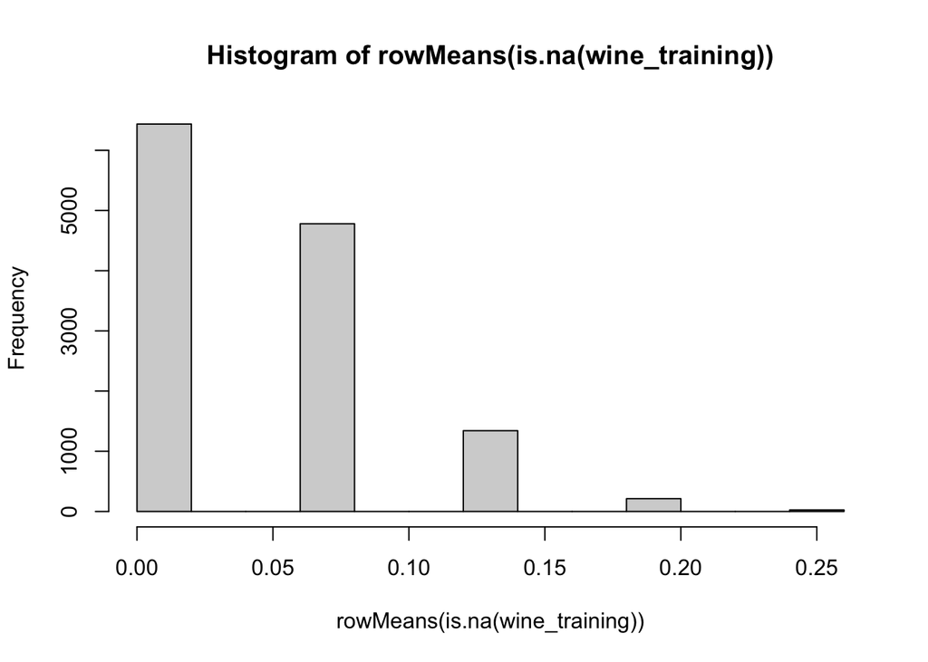

```r
hist(rowMeans(is.na(wine_training)))
```

For more than 6000 wines we have complete information

For around 5000 wines we have 6-7% of NAs, etc.

Missing valus by columns:

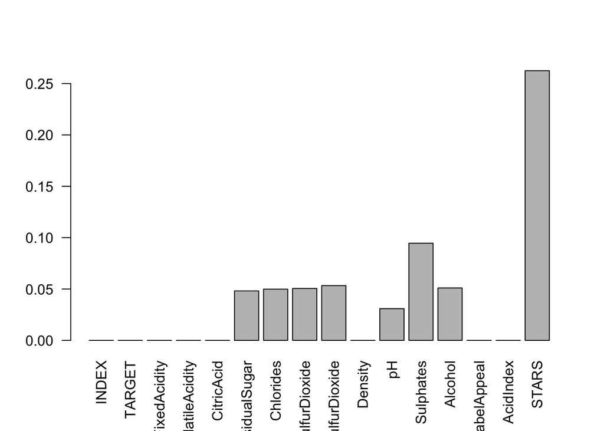

```r
barplot(colMeans(is.na(wine_training)), las=2)
```

The variable STARS has many missing values (around 26%)

We can drop it or interpret a missing value as a bad rating

Hence, we are going to:

- remove first variable (just the ID)
- convert the NAs of STARS into 1
- remove the rest of wine observations with NA

```r
wine_training = wine_training %>%
  mutate(STARS = ifelse(is.na(STARS), 1, STARS)) %>%
  dplyr::select(-INDEX) %>%
  na.omit()

wine_testing = wine_testing %>%
  mutate(STARS = ifelse(is.na(STARS), 1, STARS)) %>%
  dplyr::select(-IN,-TARGET) %>%
  na.omit()
```

Take a look at STARS vs TARGET:

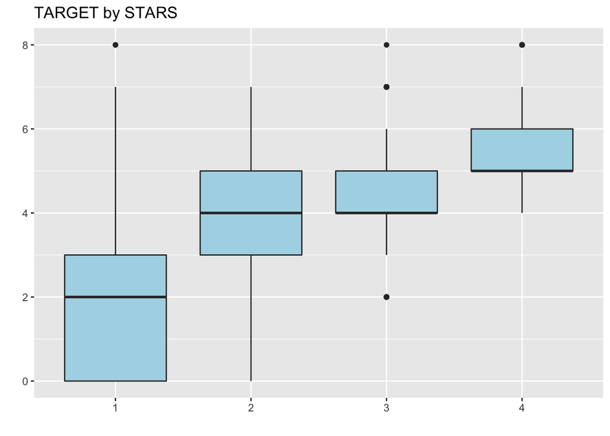

```r
wine_training %>%
  ggplot(aes(x = as.factor(STARS), y = TARGET)) +
  geom_boxplot(fill="lightblue") +
  labs(title = "TARGET by STARS", x = "", y = "", col = "")
```

# Descriptive analysis

Around 80% of wines for training and the other 20% for testing:

```r
dim(wine_training)
```

```
## [1] 8675   15
```

```r
dim(wine_testing)
```

```
## [1] 2286   14
```

Let’s analyze the unconditional distribution of the target (number of wine cases purchased):

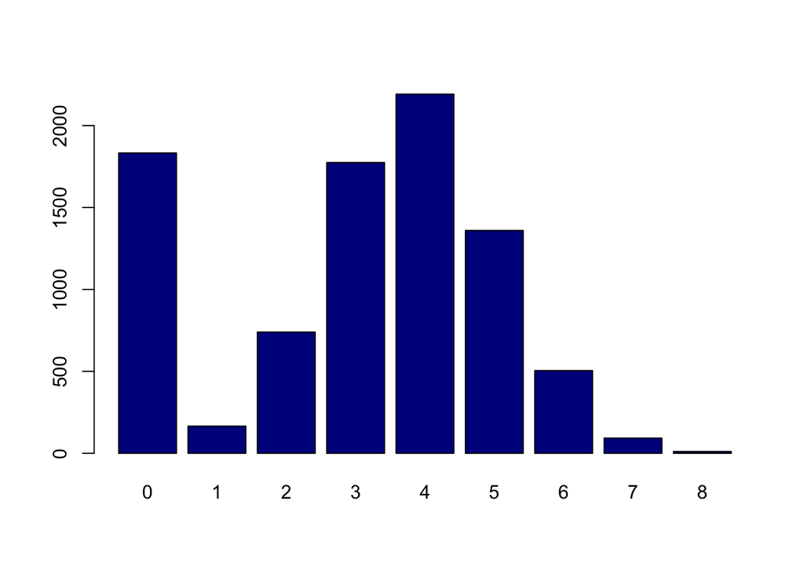

```r
barplot(table(wine_training$TARGET), col="darkblue")
```

zero-inflated? clearly non-normal distribution

Let’s see now some conditional distributions

First respect to fixed acidity

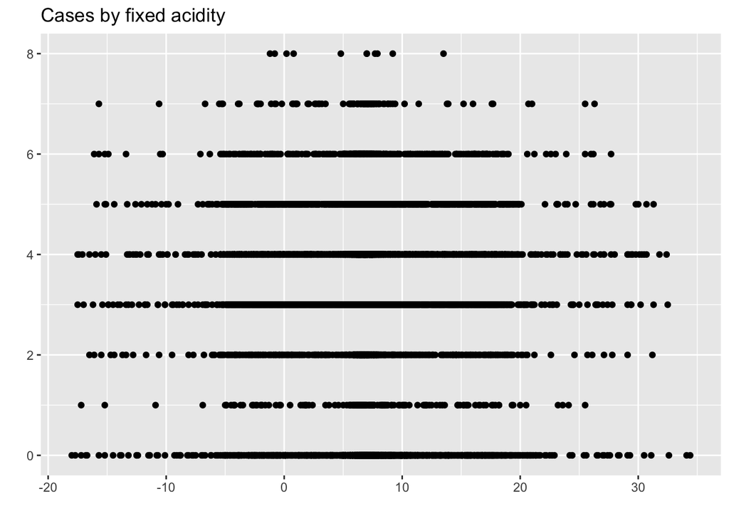

```r
wine_training %>%
  ggplot(aes(x = FixedAcidity, y = TARGET)) +
  geom_point(fill="lightblue") +
  labs(title = "Cases by fixed acidity", x = "", y = "", col = "")
```

We can try many other graphs…

Let’s make multiple scatter-plots

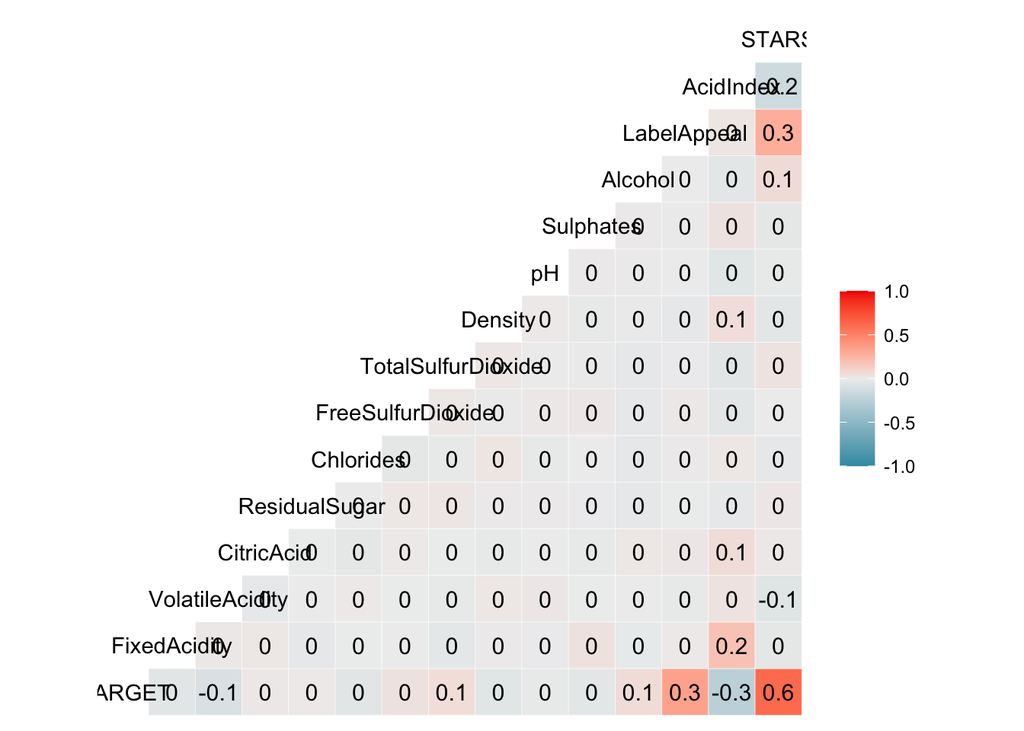

```r
ggcorr(wine_training, label = T)
```

As we could expect, STARS and LabelAppeal have positive correlations with TARGET

Note also AcidIndex has a slightly negative correlation with TARGET

The rest of correlations are close to 0

Finally, convert STARS into a factor variable

```r
wine_training$STARS = as.factor(wine_training$STARS)
wine_testing$STARS = as.factor(wine_testing$STARS)
```

# GLM

Let’s fit first a linear model:

```r
fit.lm <- lm(TARGET ~ ., data=wine_training)
summary(fit.lm)
```

```
##
## Call:
## lm(formula = TARGET ~ ., data = wine_training)
##
## Residuals:
##     Min      1Q  Median      3Q     Max
## -4.8178 -0.9922  0.0694  0.9964  5.5411
##
## Coefficients:
##                      Estimate Std. Error t value Pr(>|t|)
## (Intercept)         4.970e+00  5.704e-01   8.713  < 2e-16 ***
## FixedAcidity        1.120e-03  2.424e-03   0.462 0.643959
## VolatileAcidity    -1.064e-01  1.910e-02  -5.569 2.63e-08 ***
## CitricAcid          1.164e-02  1.745e-02   0.667 0.504631
## ResidualSugar      -1.918e-04  4.418e-04  -0.434 0.664148
## Chlorides          -1.755e-01  4.678e-02  -3.751 0.000177 ***
## FreeSulfurDioxide   3.368e-04  1.009e-04   3.339 0.000845 ***
## TotalSulfurDioxide  2.986e-04  6.515e-05   4.584 4.63e-06 ***
## Density            -1.155e+00  5.640e-01  -2.049 0.040531 *
## pH                 -3.766e-02  2.203e-02  -1.710 0.087352 .
## Sulphates          -3.756e-02  1.609e-02  -2.334 0.019630 *
## Alcohol             1.242e-02  4.060e-03   3.058 0.002232 **
## LabelAppeal         4.385e-01  1.767e-02  24.817  < 2e-16 ***
## AcidIndex          -2.327e-01  1.161e-02 -20.052  < 2e-16 ***
## STARS2              1.716e+00  3.583e-02  47.892  < 2e-16 ***
## STARS3              2.278e+00  4.312e-02  52.829  < 2e-16 ***
## STARS4              3.009e+00  7.563e-02  39.793  < 2e-16 ***
## ---
## Signif. codes:  0 '***' 0.001 '**' 0.01 '*' 0.05 '.' 0.1 ' ' 1
##
## Residual standard error: 1.393 on 8658 degrees of freedom
## Multiple R-squared:  0.4721, Adjusted R-squared:  0.4711
## F-statistic: 483.9 on 16 and 8658 DF,  p-value: < 2.2e-16
```

The R2 is 47%, reasonable fit

Diagnosis

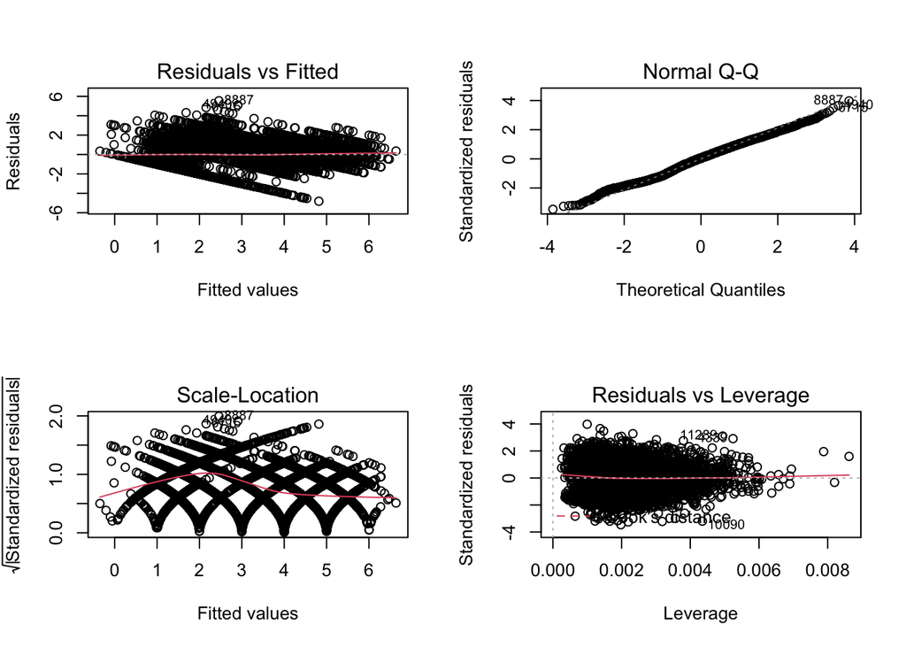

```r
par(mfrow=c(2,2))
plot(fit.lm)
```

```r
par(mfrow=c(1,1))
```

Clearly not a good model…

But take care: if rates or counts are clearly bigger than 0, then LM may work fine

Let’s try now a linear model with log transformation

Take care: the target has 0 values

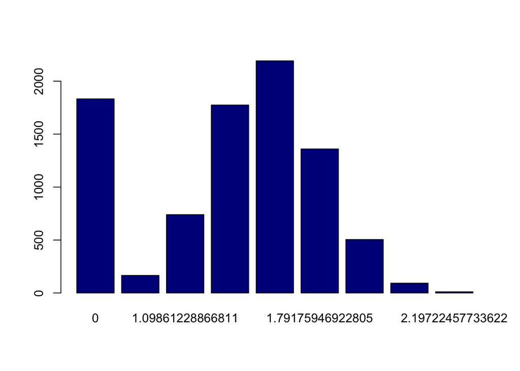

```r
barplot(table(log(wine_training$TARGET+1)), col="darkblue")
```

```r
fit.lm <- lm(log(TARGET+1) ~ ., data=wine_training)
summary(fit.lm)
```

```
##
## Call:
## lm(formula = log(TARGET + 1) ~ ., data = wine_training)
##
## Residuals:
##      Min       1Q   Median       3Q      Max
## -1.68621 -0.27277  0.04717  0.35677  1.45302
##
## Coefficients:
##                      Estimate Std. Error t value Pr(>|t|)
## (Intercept)         1.950e+00  2.138e-01   9.122  < 2e-16 ***
## FixedAcidity        3.568e-04  9.085e-04   0.393 0.694546
## VolatileAcidity    -3.726e-02  7.158e-03  -5.205 1.99e-07 ***
## CitricAcid          6.321e-03  6.541e-03   0.966 0.333853
## ResidualSugar       2.414e-05  1.656e-04   0.146 0.884113
## Chlorides          -6.218e-02  1.753e-02  -3.546 0.000393 ***
## FreeSulfurDioxide   1.276e-04  3.781e-05   3.373 0.000746 ***
## TotalSulfurDioxide  1.405e-04  2.442e-05   5.756 8.93e-09 ***
## Density            -3.258e-01  2.114e-01  -1.541 0.123254
## pH                 -2.339e-02  8.256e-03  -2.833 0.004627 **
## Sulphates          -1.742e-02  6.032e-03  -2.887 0.003894 **
## Alcohol             8.107e-04  1.522e-03   0.533 0.594160
## LabelAppeal         5.705e-02  6.622e-03   8.615  < 2e-16 ***
## AcidIndex          -9.113e-02  4.350e-03 -20.950  < 2e-16 ***
## STARS2              6.545e-01  1.343e-02  48.734  < 2e-16 ***
## STARS3              7.886e-01  1.616e-02  48.803  < 2e-16 ***
## STARS4              9.242e-01  2.834e-02  32.607  < 2e-16 ***
## ---
## Signif. codes:  0 '***' 0.001 '**' 0.01 '*' 0.05 '.' 0.1 ' ' 1
##
## Residual standard error: 0.5221 on 8658 degrees of freedom
## Multiple R-squared:  0.4034, Adjusted R-squared:  0.4023
## F-statistic: 365.9 on 16 and 8658 DF,  p-value: < 2.2e-16
```

The R2 is 40%, reasonable fit

Diagnosis

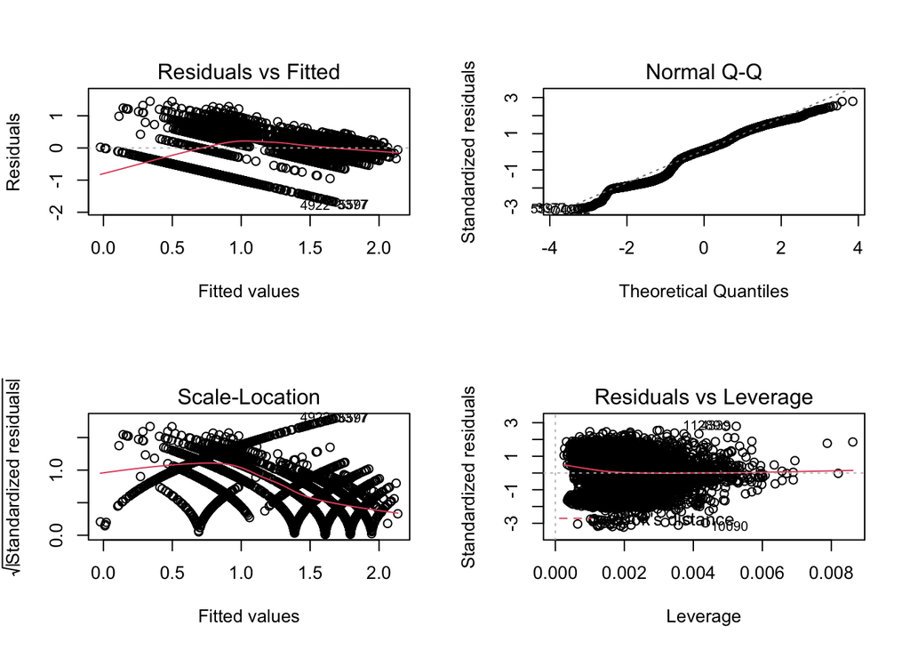

```r
par(mfrow=c(2,2))
plot(fit.lm)
```

```r
par(mfrow=c(1,1))
```

Still, not so good: the high number of zeros makes the linear model (even with log) a bad choice

# Poisson Regression

Used for count data (e.g. number of wine cases) or rates (number of wine sales per month)

```r
fit.poisson <- glm(TARGET ~ ., family = "poisson", data = wine_training)
# by default we are using the log link

summary(fit.poisson)
```

```
##
## Call:
## glm(formula = TARGET ~ ., family = "poisson", data = wine_training)
##
## Deviance Residuals:
##     Min       1Q   Median       3Q      Max
## -3.2550  -0.6318   0.0401   0.5772   2.9706
##
## Coefficients:
##                      Estimate Std. Error z value Pr(>|z|)
## (Intercept)         1.791e+00  2.368e-01   7.564 3.92e-14 ***
## FixedAcidity        1.380e-04  1.000e-03   0.138 0.890266
## VolatileAcidity    -3.516e-02  7.898e-03  -4.452 8.51e-06 ***
## CitricAcid          3.893e-03  7.182e-03   0.542 0.587716
## ResidualSugar      -5.562e-05  1.827e-04  -0.304 0.760845
## Chlorides          -5.805e-02  1.933e-02  -3.004 0.002668 **
## FreeSulfurDioxide   1.123e-04  4.161e-05   2.698 0.006981 **
## TotalSulfurDioxide  1.026e-04  2.694e-05   3.810 0.000139 ***
## Density            -3.989e-01  2.332e-01  -1.711 0.087130 .
## pH                 -1.456e-02  9.091e-03  -1.601 0.109332
## Sulphates          -1.511e-02  6.649e-03  -2.273 0.023049 *
## Alcohol             3.373e-03  1.679e-03   2.009 0.044559 *
## LabelAppeal         1.482e-01  7.421e-03  19.968  < 2e-16 ***
## AcidIndex          -9.260e-02  5.472e-03 -16.923  < 2e-16 ***
## STARS2              6.390e-01  1.546e-02  41.324  < 2e-16 ***
## STARS3              7.569e-01  1.711e-02  44.246  < 2e-16 ***
## STARS4              8.811e-01  2.547e-02  34.599  < 2e-16 ***
## ---
## Signif. codes:  0 '***' 0.001 '**' 0.01 '*' 0.05 '.' 0.1 ' ' 1
##
## (Dispersion parameter for poisson family taken to be 1)
##
##     Null deviance: 15334  on 8674  degrees of freedom
## Residual deviance: 10332  on 8658  degrees of freedom
## AIC: 32079
##
## Number of Fisher Scoring iterations: 5
```

## Interpretation

Fitted model: $\log(\lambda_i) = x_i'\ \beta$

The same for the rest of variables:

```r
exp(cbind(coef(fit.poisson), confint(fit.poisson)))
```

```
##                                  2.5 %    97.5 %
## (Intercept)        5.9951797 3.7687233 9.5344182
## FixedAcidity       1.0001380 0.9981788 1.0021010
## VolatileAcidity    0.9654486 0.9506190 0.9805112
## CitricAcid         1.0039011 0.9898699 1.0181317
## ResidualSugar      0.9999444 0.9995864 1.0003026
## Chlorides          0.9436057 0.9085315 0.9800311
## FreeSulfurDioxide  1.0001123 1.0000307 1.0001938
## TotalSulfurDioxide 1.0001026 1.0000498 1.0001554
## Density            0.6710256 0.4248899 1.0599323
## pH                 0.9855484 0.9681433 1.0032672
## Sulphates          0.9850028 0.9722511 0.9979247
## Alcohol            1.0033790 1.0000823 1.0066872
## LabelAppeal        1.1597323 1.1429854 1.1767245
## AcidIndex          0.9115547 0.9018047 0.9213568
## STARS2             1.8945962 1.8380556 1.9529187
## STARS3             2.1316813 2.0613693 2.2043427
## STARS4             2.4135499 2.2955772 2.5365754
```

Note values close to 1 are not significant

Note also that, after discounting for chemical variables, LabelAppeal and STARS are still significant

Meaning?

In any case, the model explains only 30% of the deviance: 1-10332/15334

This is like a pseudo-R2: 1-Residual.deviance/Null.deviance

AIC: 32079

Consider now a Poisson regression with the most significant variables:

```r
fit.poisson <- glm(TARGET ~ VolatileAcidity + Chlorides +
                     TotalSulfurDioxide + FreeSulfurDioxide +
                     AcidIndex + LabelAppeal*STARS,
                   family = "poisson", data = wine_training)
summary(fit.poisson)
```

```
##
## Call:
## glm(formula = TARGET ~ VolatileAcidity + Chlorides + TotalSulfurDioxide +
##     FreeSulfurDioxide + AcidIndex + LabelAppeal * STARS, family = "poisson",
##     data = wine_training)
##
## Deviance Residuals:
##     Min       1Q   Median       3Q      Max
## -3.5083  -0.6415   0.0327   0.5782   3.1729
##
## Coefficients:
##                      Estimate Std. Error z value Pr(>|z|)
## (Intercept)         1.359e+00  4.401e-02  30.880  < 2e-16 ***
## VolatileAcidity    -3.420e-02  7.904e-03  -4.327 1.51e-05 ***
## Chlorides          -5.907e-02  1.928e-02  -3.064  0.00218 **
## TotalSulfurDioxide  9.708e-05  2.691e-05   3.607  0.00031 ***
## FreeSulfurDioxide   1.062e-04  4.159e-05   2.553  0.01069 *
## AcidIndex          -9.164e-02  5.390e-03 -17.002  < 2e-16 ***
## LabelAppeal         6.992e-02  1.264e-02   5.529 3.22e-08 ***
## STARS2              6.414e-01  1.564e-02  41.014  < 2e-16 ***
## STARS3              7.614e-01  1.796e-02  42.387  < 2e-16 ***
## STARS4              9.088e-01  3.319e-02  27.381  < 2e-16 ***
## LabelAppeal:STARS2  1.421e-01  1.790e-02   7.938 2.05e-15 ***
## LabelAppeal:STARS3  1.025e-01  1.963e-02   5.224 1.75e-07 ***
## LabelAppeal:STARS4  6.317e-02  3.093e-02   2.043  0.04110 *
## ---
## Signif. codes:  0 '***' 0.001 '**' 0.01 '*' 0.05 '.' 0.1 ' ' 1
##
## (Dispersion parameter for poisson family taken to be 1)
##
##     Null deviance: 15334  on 8674  degrees of freedom
## Residual deviance: 10281  on 8662  degrees of freedom
## AIC: 32020
##
## Number of Fisher Scoring iterations: 5
```

The AIC is a bit better: 32020

## Interpretation with the effects package

STARS effect on target:

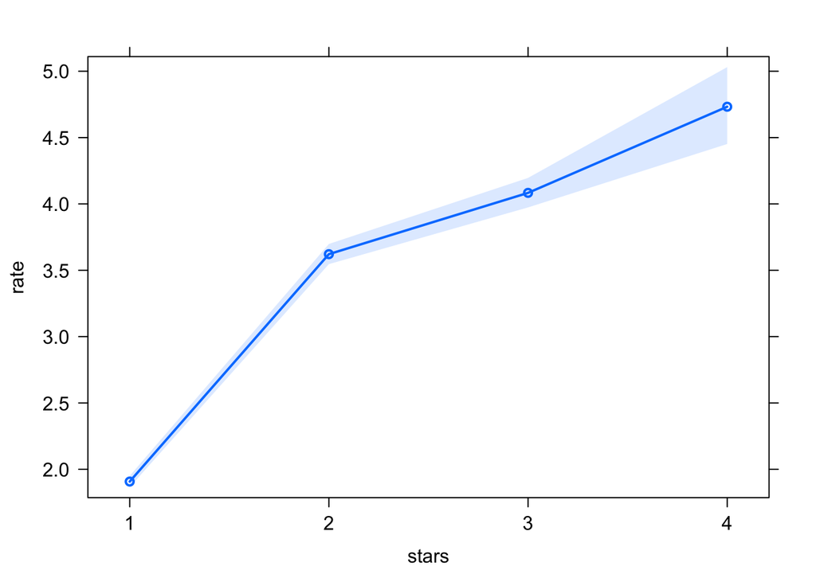

```r
plot(effect("STARS", fit.poisson), ci.style="band", rescale.axis=FALSE, multiline=TRUE, xlab="stars", ylab="rate", rug=FALSE, main="")
```

a very clear relation

LabelAppeal effect on target:

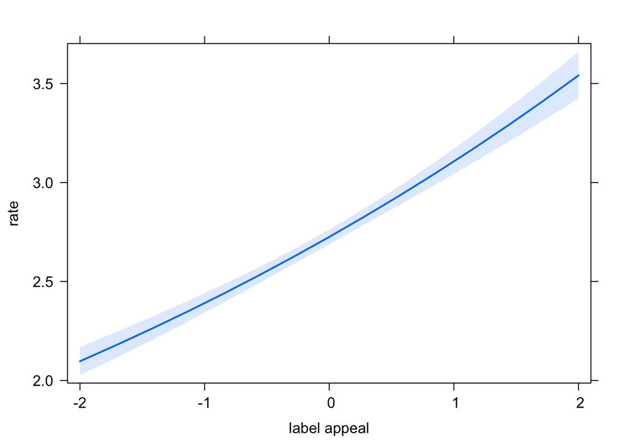

```r
plot(effect("LabelAppeal", fit.poisson), ci.style="band", rescale.axis=FALSE, multiline=TRUE, xlab="label appeal", ylab="rate", rug=FALSE, main="")
```

a very clear (but weaker) relation

Interaction effect

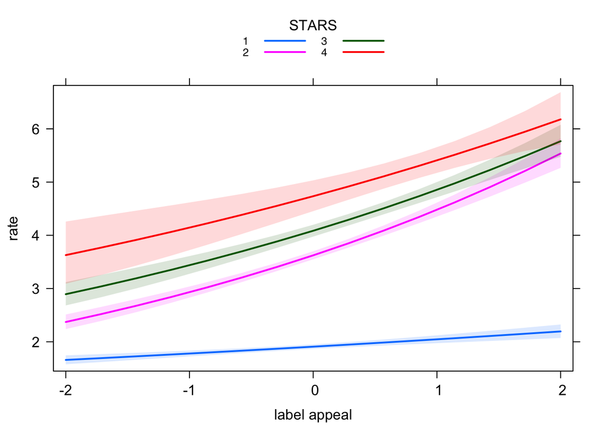

```r
plot(effect("LabelAppeal:STARS", fit.poisson), ci.style="band", rescale.axis=FALSE, multiline=TRUE, xlab="label appeal", ylab="rate", rug=FALSE, main="")
```

a very clear relation

All effects on target:

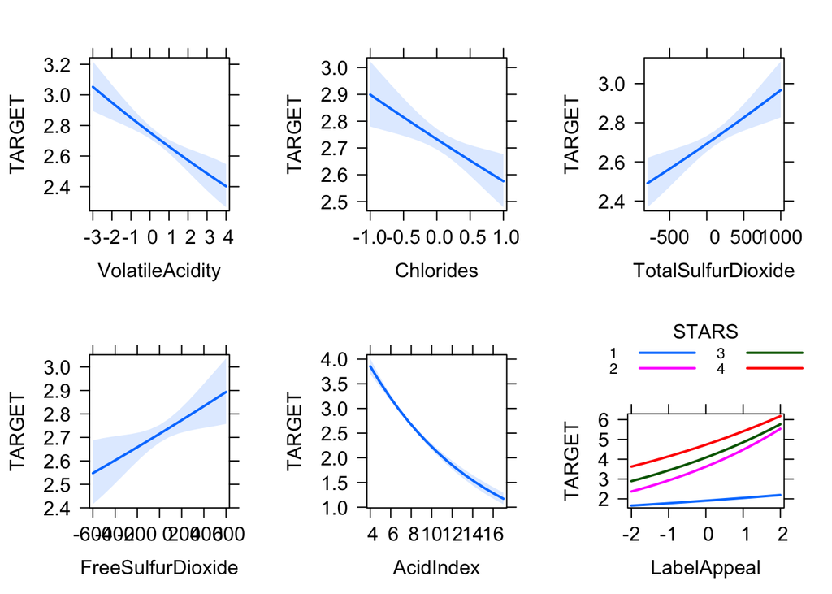

```r
plot(allEffects(fit.poisson), rescale.axis=FALSE, multiline=TRUE, rug=FALSE, main="")
```

Insights?

# Quasi-Poisson Regression

Useful to deal with over-dispersion

```r
fit.qpoisson <- glm(TARGET ~ VolatileAcidity + Chlorides + TotalSulfurDioxide + FreeSulfurDioxide + AcidIndex + LabelAppeal*STARS, family = "quasipoisson", data = wine_training)
summary(fit.qpoisson)
```

```
##
## Call:
## glm(formula = TARGET ~ VolatileAcidity + Chlorides + TotalSulfurDioxide +
##     FreeSulfurDioxide + AcidIndex + LabelAppeal * STARS, family = "quasipoisson",
##     data = wine_training)
##
## Deviance Residuals:
##     Min       1Q   Median       3Q      Max
## -3.5083  -0.6415   0.0327   0.5782   3.1729
##
## Coefficients:
##                      Estimate Std. Error t value Pr(>|t|)
## (Intercept)         1.359e+00  4.176e-02  32.546  < 2e-16 ***
## VolatileAcidity    -3.420e-02  7.499e-03  -4.561 5.17e-06 ***
## Chlorides          -5.907e-02  1.829e-02  -3.230 0.001245 **
## TotalSulfurDioxide  9.708e-05  2.554e-05   3.802 0.000145 ***
## FreeSulfurDioxide   1.062e-04  3.946e-05   2.690 0.007151 **
## AcidIndex          -9.164e-02  5.114e-03 -17.920  < 2e-16 ***
## LabelAppeal         6.992e-02  1.200e-02   5.828 5.83e-09 ***
## STARS2              6.414e-01  1.484e-02  43.228  < 2e-16 ***
## STARS3              7.614e-01  1.704e-02  44.675  < 2e-16 ***
## STARS4              9.088e-01  3.149e-02  28.858  < 2e-16 ***
## LabelAppeal:STARS2  1.421e-01  1.698e-02   8.367  < 2e-16 ***
## LabelAppeal:STARS3  1.025e-01  1.862e-02   5.506 3.78e-08 ***
## LabelAppeal:STARS4  6.317e-02  2.935e-02   2.153 0.031366 *
## ---
## Signif. codes:  0 '***' 0.001 '**' 0.01 '*' 0.05 '.' 0.1 ' ' 1
##
## (Dispersion parameter for quasipoisson family taken to be 0.9002046)
##
##     Null deviance: 15334  on 8674  degrees of freedom
## Residual deviance: 10281  on 8662  degrees of freedom
## AIC: NA
##
## Number of Fisher Scoring iterations: 5
```

Practically the same as before. Note phi (dispersion parameter of QP) is 0.90

# Negative Binomial Regression

Useful to deal with over-dispersion

```r
fit.nb <- glm.nb(TARGET ~ VolatileAcidity + Chlorides + TotalSulfurDioxide + FreeSulfurDioxide + AcidIndex + LabelAppeal*STARS, data = wine_training)
summary(fit.nb)
```

```
##
## Call:
## glm.nb(formula = TARGET ~ VolatileAcidity + Chlorides + TotalSulfurDioxide +
##     FreeSulfurDioxide + AcidIndex + LabelAppeal * STARS, data = wine_training,
##     init.theta = 47043.31138, link = log)
##
## Deviance Residuals:
##     Min       1Q   Median       3Q      Max
## -3.5081  -0.6414   0.0327   0.5782   3.1728
##
## Coefficients:
##                      Estimate Std. Error z value Pr(>|z|)
## (Intercept)         1.359e+00  4.402e-02  30.879  < 2e-16 ***
## VolatileAcidity    -3.420e-02  7.904e-03  -4.327 1.51e-05 ***
## Chlorides          -5.907e-02  1.928e-02  -3.064  0.00218 **
## TotalSulfurDioxide  9.708e-05  2.692e-05   3.607  0.00031 ***
## FreeSulfurDioxide   1.062e-04  4.159e-05   2.553  0.01069 *
## AcidIndex          -9.165e-02  5.391e-03 -17.001  < 2e-16 ***
## LabelAppeal         6.992e-02  1.265e-02   5.529 3.22e-08 ***
## STARS2              6.414e-01  1.564e-02  41.012  < 2e-16 ***
## STARS3              7.614e-01  1.796e-02  42.385  < 2e-16 ***
## STARS4              9.088e-01  3.319e-02  27.379  < 2e-16 ***
## LabelAppeal:STARS2  1.421e-01  1.790e-02   7.938 2.05e-15 ***
## LabelAppeal:STARS3  1.025e-01  1.963e-02   5.224 1.75e-07 ***
## LabelAppeal:STARS4  6.317e-02  3.093e-02   2.042  0.04111 *
## ---
## Signif. codes:  0 '***' 0.001 '**' 0.01 '*' 0.05 '.' 0.1 ' ' 1
##
## (Dispersion parameter for Negative Binomial(47043.31) family taken to be 1)
##
##     Null deviance: 15334  on 8674  degrees of freedom
## Residual deviance: 10280  on 8662  degrees of freedom
## AIC: 32022
##
## Number of Fisher Scoring iterations: 1
##
##
##               Theta:  47043
##           Std. Err.:  57138
## Warning while fitting theta: iteration limit reached
##
##  2 x log-likelihood:  -31993.94
```

Practically the same as before. Note theta (shape parameter of NB) is 47000, but possibly not significant

Why?

Indeed there is no big over-dispersion:

```r
mean(wine_training$TARGET)
```

```
## [1] 3.032622
```

```r
var(wine_training$TARGET)
```

```
## [1] 3.669791
```

```r
mean(wine_training$TARGET)/var(wine_training$TARGET)
```

```
## [1] 0.8263747
```

# Zero-inflated Poisson model

Useful to deal with more 0’s than expected

```r
fit.zip1 <- zeroinfl(TARGET ~ VolatileAcidity + Chlorides + TotalSulfurDioxide + FreeSulfurDioxide + AcidIndex + LabelAppeal+LabelAppeal:STARS, dist = "poisson", data = wine_training)
summary(fit.zip1)
```

```
##
## Call:
## zeroinfl(formula = TARGET ~ VolatileAcidity + Chlorides + TotalSulfurDioxide +
##     FreeSulfurDioxide + AcidIndex + LabelAppeal + LabelAppeal:STARS,
##     data = wine_training, dist = "poisson")
##
## Pearson residuals:
##     Min      1Q  Median      3Q     Max
## -1.9305 -0.3415  0.1782  0.4674  5.3018
##
## Count model coefficients (poisson with log link):
##                      Estimate Std. Error z value Pr(>|z|)
## (Intercept)         1.538e+00  4.600e-02  33.447  < 2e-16 ***
## VolatileAcidity    -2.159e-02  8.237e-03  -2.621 0.008773 **
## Chlorides          -2.529e-02  2.039e-02  -1.241 0.214739
## TotalSulfurDioxide -1.204e-05  2.725e-05  -0.442 0.658615
## FreeSulfurDioxide   6.533e-08  4.269e-05   0.002 0.998779
## AcidIndex          -3.214e-02  6.011e-03  -5.347 8.93e-08 ***
## LabelAppeal         4.176e-01  1.313e-02  31.800  < 2e-16 ***
## LabelAppeal:STARS2 -1.933e-01  1.835e-02 -10.532  < 2e-16 ***
## LabelAppeal:STARS3 -1.628e-01  1.930e-02  -8.436  < 2e-16 ***
## LabelAppeal:STARS4 -9.129e-02  2.407e-02  -3.793 0.000149 ***
##
## Zero-inflation model coefficients (binomial with logit link):
##                      Estimate Std. Error z value Pr(>|z|)
## (Intercept)        -5.5943145  0.2171178 -25.766  < 2e-16 ***
## VolatileAcidity     0.2215684  0.0460483   4.812 1.50e-06 ***
## Chlorides           0.2824481  0.1152709   2.450  0.01427 *
## TotalSulfurDioxide -0.0010099  0.0001586  -6.368 1.91e-10 ***
## FreeSulfurDioxide  -0.0006985  0.0002442  -2.861  0.00423 **
## AcidIndex           0.4915452  0.0254459  19.317  < 2e-16 ***
## LabelAppeal         1.3602358  0.0928889  14.644  < 2e-16 ***
## LabelAppeal:STARS2 -1.3998286  0.1172264 -11.941  < 2e-16 ***
## LabelAppeal:STARS3 -1.9960050  0.1381401 -14.449  < 2e-16 ***
## LabelAppeal:STARS4 -2.9921277  0.3146232  -9.510  < 2e-16 ***
## ---
## Signif. codes:  0 '***' 0.001 '**' 0.01 '*' 0.05 '.' 0.1 ' ' 1
##
## Number of iterations in BFGS optimization: 27
## Log-likelihood: -1.527e+04 on 20 Df
```

Note there are two outputs because the zero-inflated model is comprised of two sub-models: one for the count process and other for the zero-mass one

One model explains log(lambda) as a linear combination of predictors

The other one explains $\log(\pi/(1-\pi))$ as a linear combination of predictors

## Interpretation

```r
expCoef = data.frame(matrix(exp(coef(fit.zip1)),ncol=2))
row.names(expCoef) <- names(fit.zip1$coefficients$zero)
colnames(expCoef) <- c("Count_model","Zero_inflation_model")
expCoef
```

```
##                    Count_model Zero_inflation_model
## (Intercept)          4.6575179          0.003718948
## VolatileAcidity      0.9786439          1.248032656
## Chlorides            0.9750228          1.326372883
## TotalSulfurDioxide   0.9999880          0.998990614
## FreeSulfurDioxide    1.0000001          0.999301733
## AcidIndex            0.9683693          1.634840498
## LabelAppeal          1.5183209          3.897111993
## LabelAppeal:STARS2   0.8242284          0.246639237
## LabelAppeal:STARS3   0.8497584          0.135877034
## LabelAppeal:STARS4   0.9127515          0.050180552
```

If we focus on the zero-inflation model, the baseline odds of not selling wine cases is 0.003

If we increase the LabelAppleal by one unit, the odds is increased by 3.89

We can specify different predictors for the 0-point mass and the count component:

```r
fit.zip2 <- zeroinfl(TARGET ~ VolatileAcidity + Chlorides + TotalSulfurDioxide + FreeSulfurDioxide + AcidIndex + LabelAppeal*STARS | 1, dist = "poisson", data = wine_training)
summary(fit.zip2)
```

```
##
## Call:
## zeroinfl(formula = TARGET ~ VolatileAcidity + Chlorides + TotalSulfurDioxide +
##     FreeSulfurDioxide + AcidIndex + LabelAppeal * STARS | 1, data = wine_training,
##     dist = "poisson")
##
## Pearson residuals:
##     Min      1Q  Median      3Q     Max
## -1.6144 -0.2737  0.2120  0.5175  2.2661
##
## Count model coefficients (poisson with log link):
##                      Estimate Std. Error z value Pr(>|z|)
## (Intercept)         1.516e+00  4.937e-02  30.704  < 2e-16 ***
## VolatileAcidity    -2.332e-02  8.306e-03  -2.807  0.00499 **
## Chlorides          -3.616e-02  2.038e-02  -1.774  0.07605 .
## TotalSulfurDioxide  2.283e-05  2.741e-05   0.833  0.40488
## FreeSulfurDioxide   4.694e-05  4.307e-05   1.090  0.27575
## AcidIndex          -5.692e-02  6.459e-03  -8.812  < 2e-16 ***
## LabelAppeal         2.936e-01  1.564e-02  18.771  < 2e-16 ***
## STARS2              2.490e-01  1.834e-02  13.577  < 2e-16 ***
## STARS3              3.551e-01  2.023e-02  17.550  < 2e-16 ***
## STARS4              5.053e-01  3.442e-02  14.677  < 2e-16 ***
## LabelAppeal:STARS2 -7.861e-02  2.021e-02  -3.890  0.00010 ***
## LabelAppeal:STARS3 -1.210e-01  2.168e-02  -5.580 2.40e-08 ***
## LabelAppeal:STARS4 -1.637e-01  3.231e-02  -5.068 4.02e-07 ***
##
## Zero-inflation model coefficients (binomial with logit link):
##             Estimate Std. Error z value Pr(>|z|)
## (Intercept) -1.66688    0.03801  -43.85   <2e-16 ***
## ---
## Signif. codes:  0 '***' 0.001 '**' 0.01 '*' 0.05 '.' 0.1 ' ' 1
##
## Number of iterations in BFGS optimization: 20
## Log-likelihood: -1.559e+04 on 14 Df
```

Here no regressors for zero component

Now different regressors for zero component:

```r
fit.zip3 <- zeroinfl(TARGET ~ VolatileAcidity + Chlorides + TotalSulfurDioxide + AcidIndex + LabelAppeal*STARS | LabelAppeal+LabelAppeal:STARS, dist = "poisson", data = wine_training)
summary(fit.zip3)
```

```
##
## Call:
## zeroinfl(formula = TARGET ~ VolatileAcidity + Chlorides + TotalSulfurDioxide +
##     AcidIndex + LabelAppeal * STARS | LabelAppeal + LabelAppeal:STARS,
##     data = wine_training, dist = "poisson")
##
## Pearson residuals:
##     Min      1Q  Median      3Q     Max
## -1.9032 -0.3621  0.1286  0.5215  4.3125
##
## Count model coefficients (poisson with log link):
##                      Estimate Std. Error z value Pr(>|z|)
## (Intercept)         1.509e+00  4.675e-02  32.274  < 2e-16 ***
## VolatileAcidity    -2.744e-02  8.177e-03  -3.356  0.00079 ***
## Chlorides          -3.783e-02  2.009e-02  -1.884  0.05962 .
## TotalSulfurDioxide  4.464e-05  2.709e-05   1.648  0.09932 .
## AcidIndex          -6.566e-02  5.928e-03 -11.076  < 2e-16 ***
## LabelAppeal         4.006e-01  1.392e-02  28.774  < 2e-16 ***
## STARS2              3.200e-01  1.760e-02  18.181  < 2e-16 ***
## STARS3              4.269e-01  1.966e-02  21.716  < 2e-16 ***
## STARS4              5.758e-01  3.411e-02  16.882  < 2e-16 ***
## LabelAppeal:STARS2 -1.838e-01  1.892e-02  -9.712  < 2e-16 ***
## LabelAppeal:STARS3 -2.280e-01  2.048e-02 -11.136  < 2e-16 ***
## LabelAppeal:STARS4 -2.702e-01  3.150e-02  -8.577  < 2e-16 ***
##
## Zero-inflation model coefficients (binomial with logit link):
##                    Estimate Std. Error z value Pr(>|z|)
## (Intercept)        -2.36763    0.07263  -32.60   <2e-16 ***
## LabelAppeal         2.35799    0.10031   23.51   <2e-16 ***
## LabelAppeal:STARS2 -2.34112    0.13194  -17.74   <2e-16 ***
## LabelAppeal:STARS3 -2.90516    0.15489  -18.76   <2e-16 ***
## LabelAppeal:STARS4 -3.71532    0.33945  -10.95   <2e-16 ***
## ---
## Signif. codes:  0 '***' 0.001 '**' 0.01 '*' 0.05 '.' 0.1 ' ' 1
##
## Number of iterations in BFGS optimization: 25
## Log-likelihood: -1.518e+04 on 17 Df
```

AIC for all the models:

```r
AIC.total = c(AIC(fit.poisson), AIC(fit.qpoisson), AIC(fit.nb), AIC(fit.zip1), AIC(fit.zip2), AIC(fit.zip3))
AIC.total
```

```
## [1] 32019.74       NA 32021.94 30570.91 31205.71 30384.53
```

# Prediction

A linear model predicts the expected value of cases

A Poisson model predicts the rate or intensity, hence decimal points

Predicted vs actual using the log-transformed linear model model:

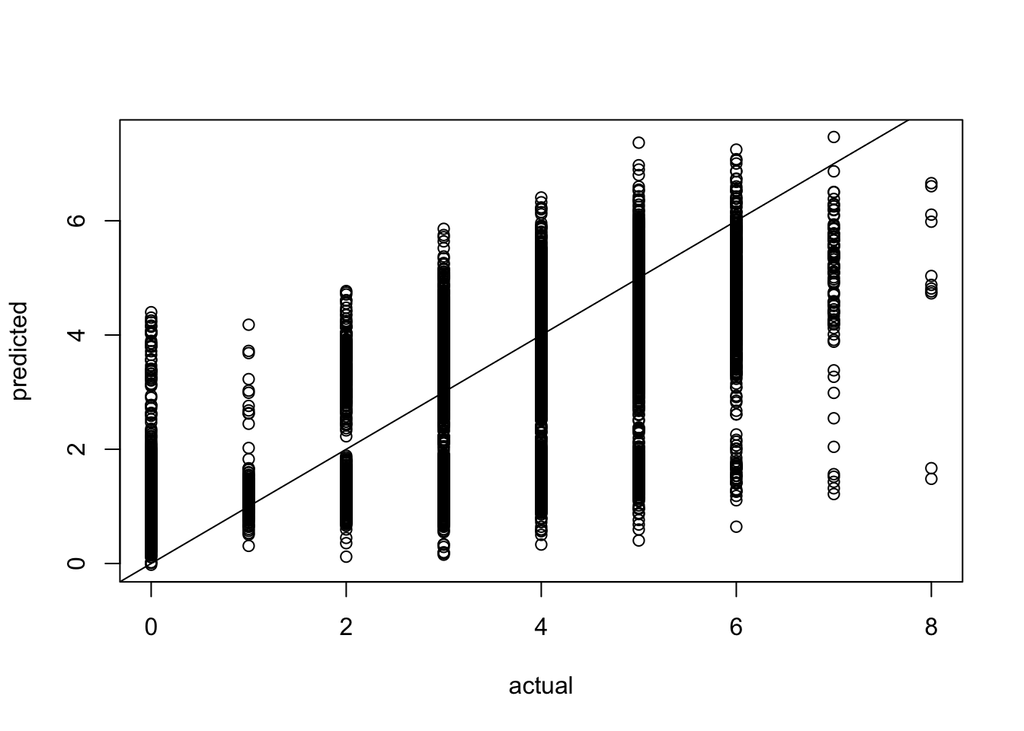

```r
plot(wine_training$TARGET, exp(predict(fit.lm, type = "response"))-1,
     xlab="actual",ylab="predicted")
abline(a=0,b=1);
```

```r
cor(wine_training$TARGET,predict(fit.lm, type = "response"))^2
```

```
## [1] 0.450334
```

Predicted vs actual using the Poisson GLM:

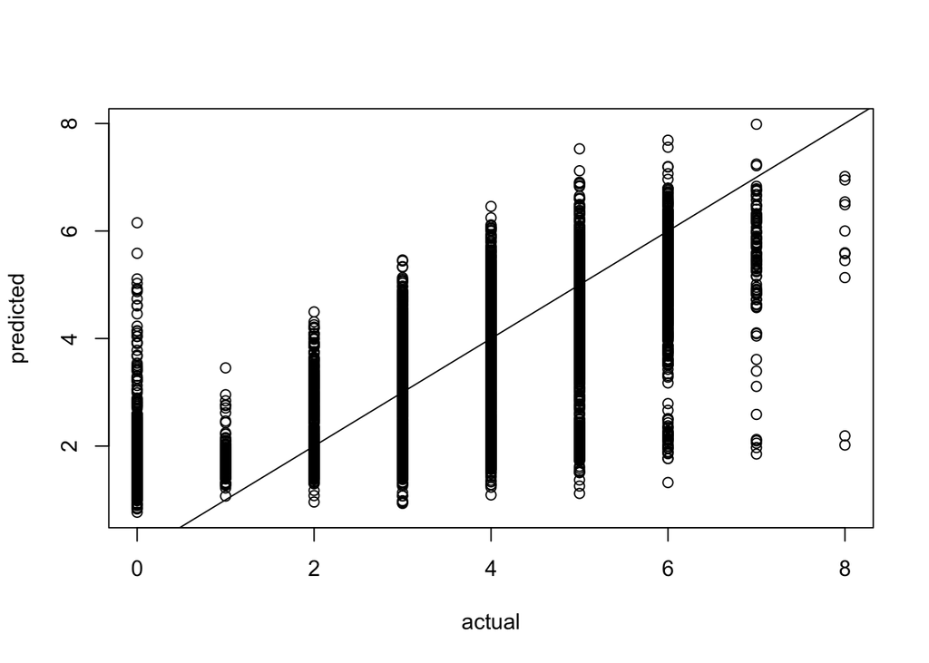

```r
plot(wine_training$TARGET, predict(fit.poisson, type = "response"),
     xlab="actual",ylab="predicted")
abline(a=0,b=1);
```

```r
cor(wine_training$TARGET,predict(fit.poisson, type = "response"))^2
```

```
## [1] 0.4707529
```

A bit better

Predicted vs actual using the Poisson zip model:

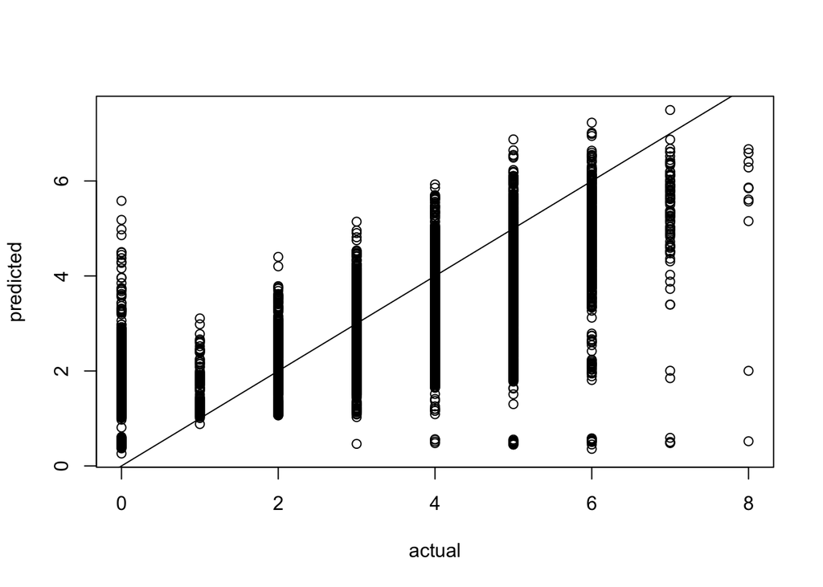

```r
plot(wine_training$TARGET, predict(fit.zip3, type = "response"),
     xlab="actual",ylab="predicted")
abline(a=0,b=1);
```

```r
cor(wine_training$TARGET,predict(fit.zip3, type = "response"))^2
```

```
## [1] 0.458833
```

A bit worse

Prediction for the wines in the testing set:

```r
predict(fit.zip3, newdata=wine_testing, type = "response")[1:10]
```

```
##        1        2        3        4        5        6        7        8
## 2.102873 3.645482 2.332344 1.789798 2.133616 5.211761 2.709289 2.132139
##        9       10
## 1.865234 2.606139
```

```r
# we should round the numbers:
predictions = round(predict(fit.zip3, newdata=wine_testing, type = "response"), digits=0)
head(predictions,20)
```

```
##  1  2  3  4  5  6  7  8  9 10 12 13 15 17 18 20 21 22 23 24
##  2  4  2  2  2  5  3  2  2  3  2  3  2  2  1  6  2  3  1  2
```

## Prediction intervals

Take care: precict.zeroinfl does not have implemented computation of intervals

We can estimate the intervals using bootstrap, but more complicated

So, let’s do it with a standard GLM

First, predict the link (linear predictor)

```r
preds = predict(fit.poisson, newdata=wine_testing, type = "link", se.fit=T)
critval <- 1.96 ## approx 95% CI
upr <- preds$fit + (critval * preds$se.fit)
lwr <- preds$fit - (critval * preds$se.fit)
fit <- preds$fit
fit[1:10]
```

```
##         1         2         3         4         5         6         7         8
## 0.8044423 1.3711965 0.5706532 0.5829291 0.4458709 1.6219738 0.9307924 0.8137272
##         9        10
## 0.2557716 0.7245971
```

Note the predictions are in log-scale

$$\hat{\mu} = g^{-1}(\text{linear predictor})$$

```r
fit2 <- fit.poisson$family$linkinv(fit)
upr2 <- fit.poisson$family$linkinv(upr)
lwr2 <- fit.poisson$family$linkinv(lwr)
fit2[1:10]
```

```
##        1        2        3        4        5        6        7        8
## 2.235449 3.940062 1.769423 1.791278 1.561850 5.063074 2.536518 2.256302
##        9       10
## 1.291458 2.063899
```

Now the predictions are in counts (but with decimal points)

Organize and round the predictions and intervals in a data frame

```r
data.frame(lower=lwr2, prediction=round(fit2,digits=0), upper=upr2)[1:10,]
```

```
##       lower prediction    upper
## 1  2.143355          2 2.331500
## 2  3.746222          4 4.143932
## 3  1.715079          2 1.825488
## 4  1.734246          2 1.850185
## 5  1.512098          2 1.613239
## 6  4.802008          5 5.338334
## 7  2.360059          3 2.726172
## 8  2.158051          2 2.359026
## 9  1.229288          1 1.356772
## 10 2.014933          2 2.114056
```

But how can we guess the predictive power of the models?

We need to build our own testing set to validate performance

```r
train <- sample(1:nrow(wine_training), round(nrow(wine_training)*0.80,0))
wine.train <- wine_training[train,]
wine.test <- wine_training[-train,]
```

GLM Poisson:

```r
fit.poisson <- glm(TARGET ~ VolatileAcidity + Chlorides + TotalSulfurDioxide + FreeSulfurDioxide + AcidIndex + LabelAppeal*STARS, family = "poisson", data = wine.train)
pred = predict(fit.poisson, newdata=wine.test, type = "response")

# conditional error:
rmse = sqrt(mean((pred-wine.test$TARGET)^2))
rmse
```

```
## [1] 1.357167
```

```r
# unconditional error:
sd(wine.test$TARGET)
```

```
## [1] 1.898783
```

```r
# R2 in testing set:
cor(pred,wine.test$TARGET)^2
```

```
## [1] 0.488998
```

ZIP Poisson

```r
fit.zip <- zeroinfl(TARGET ~ . + LabelAppeal:STARS| . , dist = "poisson", data = wine.train)
pred = predict(fit.zip, newdata=wine.test, type = "response")

# conditional error:
rmse = sqrt(mean((pred-wine.test$TARGET)^2))
rmse
```

```
## [1] 1.316248
```

```r
# unconditional error:
sd(wine.test$TARGET)
```

```
## [1] 1.898783
```

```r
# R2 in testing set:
cor(pred,wine.test$TARGET)^2
```

```
## [1] 0.5193725
```

ZIP regression is able to reduce 30% the original noise

A bit better